# Final Report

- Show All Code
- Hide All Code
- View Source

WMATA Ridership

Author

Abdullah Alghamdi, Ziqian Yang, Arman Naseh

Published

December 10, 2023

## **Sub-questions**

#### **COVID-19**

- Did the corona virus significantly impact the amount of metrorail riders? If yes, is it possible for WMATA’s metrorail riders to return to there pre-covid peaks?

#### **Weather**

- Does metrorail ridership downtrend in bad weather such as rain or snow and by how much?

### Dataset 1: Ridership

URL: https://www.wmata.com/initiatives/ridership-portal/Metrorail-Ridership-Summary.cfm

| Variable Name | Description |
| --- | --- |
| Date | Dates from 2012 to 2023 excluding holidays and some random dates |
| Entries | Total entries on a date |
| Exits | Total exits on a date |

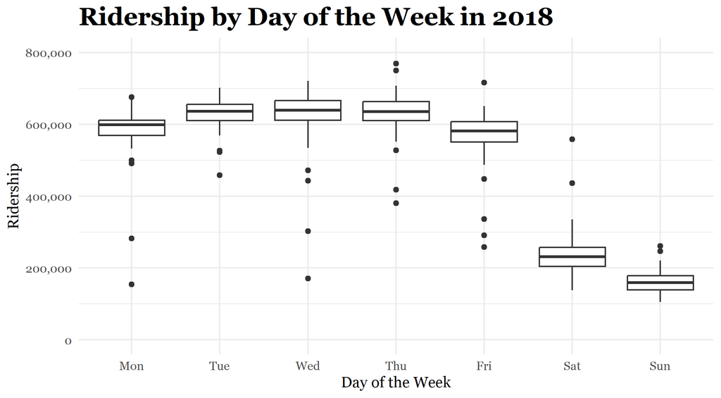

```r
ridership_data_clean <- ridership_data_raw %>%
    rename(Date = `...1`) %>%
    mutate(Date = mdy(Date))

ridership_2018 <- ridership_data_clean %>%
    filter(year(Date) == 2018) %>%
    mutate(DayOfWeek = wday(Date, label = TRUE, week_start = 1))

ggplot(ridership_2018, aes(x = DayOfWeek, y = `Total Entries`)) +
    geom_boxplot() +
    labs(title = "Ridership by Day of the Week in 2018",
         x = "Day of the Week",
         y = "Ridership") +
    theme_minimal(base_family = "Georgia") +
    theme(plot.title = element_text(size = 18, face = "bold")) +
    scale_y_continuous(
        limits = c(0, 800000),
        labels = scales::comma)
```

### Dataset 2: Weather

URL: https://www.weather.gov/wrh/Climate?wfo=lwx

Summary: The data is obtained directly from the National Weather Service website, and it is raw weather data on snowfall and precipitation. The website leads us to NOWData - NOAA Online Weather Data finder. However, it may require some data cleaning and processing to handle missing values or inconsistencies in the data. Weather data can sometimes have missing values, especially for remote or less-monitored locations.  
Validity: The data is obtained directly from the National Weather Service, which is considered a reliable and authoritative source for weather data.

| Variable Name | Description |
| --- | --- |
| Date | Date of the weather summary |
| Max Temperature | Maximum temperature for the day (°F) |
| Min Temperature | Minimum temperature for the day (°F) |
| Precipitation | Total precipitation for the day (inches) |
| Snowfall | Total snowfall for the day (inches) |
| Snow Depth | Snow depth at the end of the day (inches) |
| Wind Speed | Maximum wind speed during the day (mph) |
| Wind Direction | Predominant wind direction for the day |
| Weather Condition | Description of the weather condition (e.g., clear, rainy, snow) |

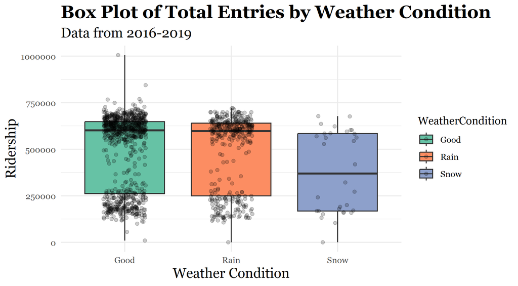

```r
combined_data <- merge(ridership_data_clean, weather_data_combined, by="Date")

# Creating a new column 'WeatherCondition' to classify the weather based on the precipitation and snowfall values
combined_data$WeatherCondition <- ifelse(combined_data$Value.x > 0 & combined_data$Value.y == 0, 'Rain',
                                         ifelse(combined_data$Value.y > 0, 'Snow', 'Good'))

combined_data_filtered <- combined_data %>% filter(!is.na(WeatherCondition))


ggplot(combined_data_filtered, aes(x = WeatherCondition, y = `Total Entries`, fill = WeatherCondition)) +
  geom_boxplot() +
  geom_jitter(width = 0.2, alpha = 0.2) + # Add points with a slight transparency
  scale_fill_brewer(palette = "Set2") + # Add color
  labs(
    title = "Box Plot of Total Entries by Weather Condition",
    subtitle = "Data from 2016-2019",
    x = "Weather Condition",
    y = "Ridership",
  ) +
  theme_minimal(base_family = "Georgia") +
  theme(
    plot.title = element_text(size = 18, face = "bold"),
    plot.subtitle = element_text(size = 14),
    axis.title = element_text(size = 14),
  )
```

The provided box plot visualizes the relationship between WMATA ridership (measured by total entries) and weather conditions from 2016 to 2019. Three distinct weather categories are considered: Good, Rain, and Snow. The analysis of this chart will explore the central tendencies, dispersion, and outliers within each category, offering insights into how weather influences public transportation usage.

Snow: The median ridership on snowy days is lower than on both good and rainy days, with an IQR similar in width to rainy days. This trend points to a more substantial impact of snow on ridership, which aligns with common challenges associated with commuting during snow, such as service disruptions, delays, and safety concerns. The spread of outliers is smaller for snowy days, which might indicate that extreme variations in ridership are less frequent under snowy conditions, potentially due to a general avoidance of travel during heavy snowfall.

Central Tendencies: Good weather is associated with the highest median ridership, suggesting it is the most favorable condition for transit use. Rain and snow show a decrease in median ridership, with snow having the most substantial impact.

Outliers: The presence of outliers in each category reveals days with atypical ridership. Under good weather, both high and low outliers suggest occasional deviations from typical commuting patterns, which could be due to special events or other non-weather-related factors. Rain and snow outliers are predominantly on the lower side, underscoring adverse weather’s potential to significantly deter ridership.

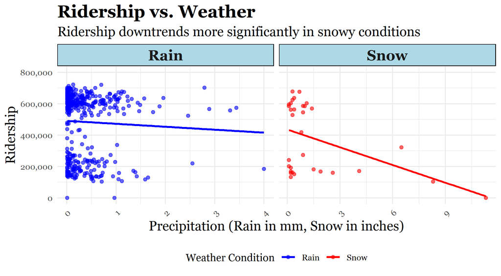

```r
combined_data_filtered <- combined_data %>%
  filter(Value.x > 0 | Value.y > 0) %>%
  mutate(WeatherType = ifelse(Value.x > 0 & Value.y == 0, "Rain", ifelse(Value.y > 0, "Snow", NA))) %>%
  # Rename columns to 'Rain' and 'Snow' for the gather function
  rename(Rain = Value.x, Snow = Value.y) %>%
  gather(key = "Condition", value = "Measurement", Rain, Snow, factor_key=TRUE) %>%
  filter(!is.na(Measurement) & Measurement > 0)

# Creating a faceted scatter plot for Total Entries vs Weather (excluding zero values)
p <- ggplot(combined_data_filtered, aes(x = Measurement, y = `Total Entries`)) +
  geom_point(aes(color = Condition), alpha = 0.6) +
  geom_smooth(method = "lm", aes(color = Condition), se = FALSE) + # Add a linear regression line without confidence interval
  facet_wrap(~Condition, scales = "free_x") + # Create facets for Rain and Snow with independent x scales
  labs(
    title = "Ridership vs. Weather",
    subtitle = "Ridership downtrends more significantly in snowy conditions",
    x = "Precipitation (Rain in mm, Snow in inches)",
    y = "Ridership"
  ) +
  scale_color_manual(values = c("Rain" = "blue", "Snow" = "red")) +
  theme_minimal(base_family = "Georgia") +
  theme(
    legend.position = "bottom",
    strip.background = element_rect(fill = "lightblue"), # Customizing facet label background
    strip.text = element_text(size = 15, face = "bold"), # Customizing facet label text
    plot.title = element_text(size = 18, face = "bold"),
    plot.subtitle = element_text(size = 14),
    axis.title = element_text(size = 14),
    axis.text.x = element_text(angle = 45, vjust = 1, hjust=1)
  ) +
  guides(color = guide_legend(title = "Weather Condition")) +
  scale_y_continuous(
        limits = c(0, 800000),
        labels = scales::comma)

# Print the plot
print(p)
```

The scatter plot depicts two distinct clusters of points, each representing a different weather condition on the x-axis, and corresponding ridership numbers on the y-axis. Here’s a deeper analysis of the observed patterns:

Rain Cluster: A dense congregation of points at the lower end of the rainfall spectrum suggests that light to moderate rain has a minimal deterrent effect on ridership. This indicates a certain level of tolerance or preparedness among commuters for these conditions. The negative slope of the trend line, however, indicates a general decrease in ridership as rainfall increases. This suggests that beyond a certain threshold, rain may discourage WMATA use, possibly due to concerns over delays, safety, or the discomfort of traveling in wet conditions.

Snow Cluster: The snow-related data points are more spread out, with a steep negative trend line that is more pronounced than that of the rain. This implies a stronger correlation between snowfall and a decrease in ridership. This can be attributed to the disruptive impact of snow on transportation infrastructure, including road closures, reduced visibility, and potential delays or cancellations of transit services. The impact of even a small amount of snow appears significant, likely due to the cumulative effects of snow on the city’s ability to maintain normal transit operations.

Linear Regression Trends: The trend lines for both rain and snow reveal valuable information. For rain, the more gradual slope suggests a more linear relationship between the increase in precipitation and a decrease in ridership. For snow, the steeper slope implies that ridership is more sensitive to changes in snowfall amounts, with even minor increases potentially resulting in significant drops in ridership.

Data Point Density and Spread: The density of data points for rain indicates that the most common weather events involve less precipitation, whereas snow events are more variable in terms of their occurrence and impact. The spread of the snow data points might also reflect the less frequent but more impactful nature of snow events compared to rain.

### COVID-19

[figure not shown]

```r
#| fig.width: 12
#| fig.height: 8

ggplot(ridership_data_clean, aes(x = Date, y = `Total Entries`)) +
    geom_line(color = "darkred") +
    labs(title = "How has the COVID-19 Pandemic Affected DC Metro Ridership?",
         subtitle = "2018-2023",
         x = "Date",
         y = "Ridership") +
    scale_x_date(
        date_breaks = "1 year",
        date_labels = "%Y",
        limits = as.Date(c("2015-01-01", "2023-12-31"))
    ) +
    scale_y_continuous(
        limits = c(0, 800000),
        labels = scales::comma
    ) +
    theme_classic(base_family = "Georgia",
                  base_size = 16) +
    theme(
    plot.title = element_text(size = 18, face = "bold"),
    plot.subtitle = element_text(size = 14))
```

Public transportation in the US has been on the downtrend slowly over the years and the DC Metrorail is no exception to this. It can be seen in the pre-covid era, ridership is very slowly decreasing or just static even though more stations were opening up and trains being made. The immediate spikes and plummets all over the line graph in each year are the result of weekends having much lower amounts of riders. In 2020, as a result of quarantine in the COVID-19 pandemic, many stations were probably closed because there was no one to operate them which results in averages as low as around 15,000 riders daily. However, in post-covid it seems that ridership is on the track to a healthy recovery but will most likely not be able to achieve the same ridership as pre-covid as a result of work from home and company policies changing to not need as many employees to be physically present on a day-to-day basis.

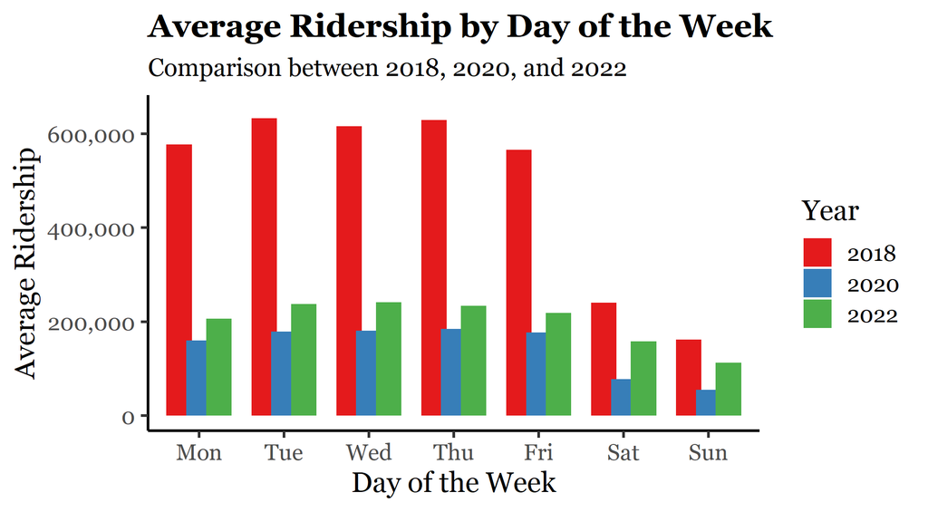

```r
average_ridership_by_day <- ridership_data_clean %>%
    filter(year(Date) %in% c(2018, 2020, 2022)) %>%
    mutate(Year = as.factor(year(Date)),
           DayOfWeek = wday(Date, label = TRUE, week_start = 1)) %>%
    group_by(Year, DayOfWeek) %>%
    summarise(AverageRidership = mean(`Total Entries`, na.rm = TRUE)) %>%
    ungroup()

# Create the bar chart
ggplot(average_ridership_by_day, aes(x = DayOfWeek, y = AverageRidership, fill = Year)) +
    geom_bar(stat = "identity", position = position_dodge(width = 0.7)) +
    labs(title = "Average Ridership by Day of the Week",
         subtitle = "Comparison between 2018, 2020, and 2022",
         x = "Day of the Week",
         y = "Average Ridership") +
    scale_fill_brewer(palette = "Set1") +  # Use a distinguishable color palette
    theme_minimal() +

    theme_classic(base_family = "Georgia",
                  base_size = 16) +
    theme(
    plot.title = element_text(size = 18, face = "bold"),
    plot.subtitle = element_text(size = 14)) +

     scale_y_continuous(
        limits = c(0, 650000),
        labels = scales::comma)
```

```r
    theme(axis.text.x = element_text(angle = 45, hjust = 1))  # Improve readability of x labels
```

[output not shown]

Here we have a more direct comparison to see how far the Metrorail has fallen during peak covid compared to pre-covid activity and it is most evidently shown on weekdays. 2018 is significantly higher than the rest while 2022 doesn’t even recover enough to make up for 50% of pre-covid ridership.

### **Attribution:**

All of the final report has been done by Abdullah and Ziqian and Arman will be doing the final presentation. Abdullah was responsible for the ridership and COVID-19 sections, while Ziqian was responsible for the weather section

## **Appendix**

```r
spelling::spell_check_files("report.qmd")

# Load libraries and settings here
library(tidyverse)
library(readr)
library(readxl)
library(dplyr)
library(tidyr)
library(lubridate)
library(here)
library(ggplot2)
library(here)
library(extrafont)


knitr::opts_chunk$set(
  warning = FALSE,
  message = FALSE,
  comment = "#>",
  fig.path = "figs/", # Folder where rendered plots are saved
  fig.width = 7.252, # Default plot width
  fig.height = 4, # Default plot height
  fig.retina = 3 # For better plot resolution
)

# Put any other "global" settings here, e.g. a ggplot theme:
theme_set(theme_bw(base_size = 20))

# Write code below here to load any data used in project

ridership_data_raw <- read_excel(here("data_raw", "Total Entries and Exits.xlsx"))

ridership_data_clean <- ridership_data_raw %>%
  rename(Date = `...1`) %>%
  mutate(Date = mdy(Date))

# Reading Rainfall Data for 2016-2019

rainfall_2016 <- read_excel(here("data_raw", "Mean_Rain_Fall_By_Day_2016.xls"))
rainfall_2017 <- read_excel(here("data_raw", "Mean_Rain_Fall_By_Day_2017.xlsx"))
rainfall_2018 <- read_excel(here("data_raw", "Mean_Rain_Fall_By_Day_2018.xlsx"))
rainfall_2019 <- read_excel(here("data_raw", "Mean_Rain_Fall_By_Day_2019.xlsx"))

# Reading Snowfall Data for 2016-2019

snowfall_2016 <- read_excel(here("data_raw", "Mean Snowfall by Day 2016.xlsx"))
snowfall_2017 <- read_excel(here("data_raw", "Mean Snowfall by Day 2017.xlsx"))
snowfall_2018 <- read_excel(here("data_raw", "Mean Snowfall by Day 2018.xlsx"))
snowfall_2019 <- read_excel(here("data_raw", "Mean Snowfall by Day 2019.xlsx"))

#Weather data cleaning

#CleanRainfall_2016
rainfall_2016 <- rainfall_2016 %>%
  mutate(across(-1, ~ case_when(
    . %in% c("T", "M") ~ NA_real_,  # Replace "T" and "M" with NA
    TRUE ~ as.numeric(as.character(.))
  ))) %>%
  # If the first column is not named 'Day', rename it
  rename(Day = 1)
rainfall_long_2016 <- rainfall_2016 %>%
  pivot_longer(
    cols = -Day, # This selects all columns except for 'Day' to be pivoted
    names_to = "Month",
    values_to = "Value"
  ) %>%
  mutate(
    # Create a date column assuming the year is 2016
    Date = make_date(year = 2016, month = match(Month, month.abb), day = Day)
  ) %>%
  select(Date, Month, Value)

# Now remove rows where the Date is NA
rainfall_long_2016 <- rainfall_long_2016 %>%
  drop_na(Date)
#CleanRainfall_2017
rainfall_2017 <- rainfall_2017 %>%
  mutate(across(-1, ~ case_when(
    . %in% c("T", "M") ~ NA_real_,  # Replace "T" and "M" with NA
    TRUE ~ as.numeric(as.character(.))
  ))) %>%
  # If the first column is not named 'Day', rename it
  rename(Day = 1)
rainfall_long_2017 <- rainfall_2017 %>%
  pivot_longer(
    cols = -Day, # This selects all columns except for 'Day' to be pivoted
    names_to = "Month",
    values_to = "Value"
  ) %>%
  mutate(
    # Create a date column assuming the year is 2016
    Date = make_date(year = 2017, month = match(Month, month.abb), day = Day)
  ) %>%
  select(Date, Month, Value)

# Now remove rows where the Date is NA
rainfall_long_2017 <- rainfall_long_2017 %>%
  drop_na(Date)


#CleanRainfall_2018
rainfall_2018 <- rainfall_2018 %>%
  mutate(across(-1, ~ case_when(
    . %in% c("T", "M") ~ NA_real_,  # Replace "T" and "M" with NA
    TRUE ~ as.numeric(as.character(.))
  ))) %>%
  # If the first column is not named 'Day', rename it
  rename(Day = 1)
rainfall_long_2018 <- rainfall_2018 %>%
  pivot_longer(
    cols = -Day, # This selects all columns except for 'Day' to be pivoted
    names_to = "Month",
    values_to = "Value"
  ) %>%
  mutate(
    # Create a date column assuming the year is 2016
    Date = make_date(year = 2018, month = match(Month, month.abb), day = Day)
  ) %>%
  select(Date, Month, Value)

# Now remove rows where the Date is NA
rainfall_long_2018 <- rainfall_long_2018 %>%
  drop_na(Date)

#CleanRainfall_2019
rainfall_2019 <- rainfall_2019 %>%
  mutate(across(-1, ~ case_when(
    . %in% c("T", "M") ~ NA_real_,  # Replace "T" and "M" with NA
    TRUE ~ as.numeric(as.character(.))
  ))) %>%
  # If the first column is not named 'Day', rename it
  rename(Day = 1)
rainfall_long_2019 <- rainfall_2019 %>%
  pivot_longer(
    cols = -Day, # This selects all columns except for 'Day' to be pivoted
    names_to = "Month",
    values_to = "Value"
  ) %>%
  mutate(
    # Create a date column assuming the year is 2016
    Date = make_date(year = 2019, month = match(Month, month.abb), day = Day)
  ) %>%
  select(Date, Month, Value)

# Now remove rows where the Date is NA
rainfall_long_2019 <- rainfall_long_2019 %>%
  drop_na(Date)

#Cleansnowfall_2016
snowfall_2016 <- snowfall_2016 %>%
  mutate(across(-1, ~ case_when(
    . %in% c("T", "M") ~ NA_real_,  # Replace "T" and "M" with NA
    TRUE ~ as.numeric(as.character(.))
  ))) %>%
  # If the first column is not named 'Day', rename it
  rename(Day = 1)
snowfall_long_2016 <- snowfall_2016 %>%
  pivot_longer(
    cols = -Day, # This selects all columns except for 'Day' to be pivoted
    names_to = "Month",
    values_to = "Value"
  ) %>%
  mutate(
    # Create a date column assuming the year is 2016
    Date = make_date(year = 2016, month = match(Month, month.abb), day = Day)
  ) %>%
  select(Date, Month, Value)

# Now remove rows where the Date is NA
snowfall_long_2016 <- snowfall_long_2016 %>%
  drop_na(Date)

#Cleansnowfall_2017
snowfall_2017 <- snowfall_2017 %>%
  mutate(across(-1, ~ case_when(
    . %in% c("T", "M") ~ NA_real_,  # Replace "T" and "M" with NA
    TRUE ~ as.numeric(as.character(.))
  ))) %>%
  # If the first column is not named 'Day', rename it
  rename(Day = 1)
snowfall_long_2017 <- snowfall_2017 %>%
  pivot_longer(
    cols = -Day, # This selects all columns except for 'Day' to be pivoted
    names_to = "Month",
    values_to = "Value"
  ) %>%
  mutate(
    # Create a date column assuming the year is 2016
    Date = make_date(year = 2017, month = match(Month, month.abb), day = Day)
  ) %>%
  select(Date, Month, Value)

# Now remove rows where the Date is NA
snowfall_long_2017 <- snowfall_long_2017 %>%
  drop_na(Date)
```

```r
#Cleansnowfall_2018
snowfall_2018 <- snowfall_2018 %>%
  mutate(across(-1, ~ case_when(
    . %in% c("T", "M") ~ NA_real_,  # Replace "T" and "M" with NA
    TRUE ~ as.numeric(as.character(.))
  ))) %>%
  # If the first column is not named 'Day', rename it
  rename(Day = 1)
snowfall_long_2018 <- snowfall_2018 %>%
  pivot_longer(
    cols = -Day, # This selects all columns except for 'Day' to be pivoted
    names_to = "Month",
    values_to = "Value"
  ) %>%
  mutate(
    # Create a date column assuming the year is 2016
    Date = make_date(year = 2018, month = match(Month, month.abb), day = Day)
  ) %>%
  select(Date, Month, Value)

# Now remove rows where the Date is NA
snowfall_long_2018 <- snowfall_long_2018 %>%
  drop_na(Date)

#Cleansnowfall_2019
snowfall_2019 <- snowfall_2019 %>%
  mutate(across(-1, ~ case_when(
    . %in% c("T", "M") ~ NA_real_,  # Replace "T" and "M" with NA
    TRUE ~ as.numeric(as.character(.))
  ))) %>%
  # If the first column is not named 'Day', rename it
  rename(Day = 1)
snowfall_long_2019 <- snowfall_2019 %>%
  pivot_longer(
    cols = -Day, # This selects all columns except for 'Day' to be pivoted
    names_to = "Month",
    values_to = "Value"
  ) %>%
  mutate(
    # Create a date column assuming the year is 2016
    Date = make_date(year = 2019, month = match(Month, month.abb), day = Day)
  ) %>%
  select(Date, Month, Value)

# Now remove rows where the Date is NA
snowfall_long_2019 <- snowfall_long_2019 %>%
  drop_na(Date)

snowfall_long_combined <- bind_rows(snowfall_long_2016, snowfall_long_2017,
                                    snowfall_long_2018, snowfall_long_2019)
rainfall_long_combined <- bind_rows(rainfall_long_2016, rainfall_long_2017,
                                    rainfall_long_2018, rainfall_long_2019)

weather_data_combined <- full_join(rainfall_long_combined, snowfall_long_combined, by = "Date")

ridership_data_clean <- ridership_data_raw %>%
    rename(Date = `...1`) %>%
    mutate(Date = mdy(Date))

ridership_2018 <- ridership_data_clean %>%
    filter(year(Date) == 2018) %>%
    mutate(DayOfWeek = wday(Date, label = TRUE, week_start = 1))

ggplot(ridership_2018, aes(x = DayOfWeek, y = `Total Entries`)) +
    geom_boxplot() +
    labs(title = "Ridership by Day of the Week in 2018",
         x = "Day of the Week",
         y = "Ridership") +
    theme_minimal(base_family = "Georgia") +
    theme(plot.title = element_text(size = 18, face = "bold")) +
    scale_y_continuous(
        limits = c(0, 800000),
        labels = scales::comma)
combined_data <- merge(ridership_data_clean, weather_data_combined, by="Date")

# Creating a new column 'WeatherCondition' to classify the weather based on the precipitation and snowfall values
combined_data$WeatherCondition <- ifelse(combined_data$Value.x > 0 & combined_data$Value.y == 0, 'Rain',
                                         ifelse(combined_data$Value.y > 0, 'Snow', 'Good'))

combined_data_filtered <- combined_data %>% filter(!is.na(WeatherCondition))


ggplot(combined_data_filtered, aes(x = WeatherCondition, y = `Total Entries`, fill = WeatherCondition)) +
  geom_boxplot() +
  geom_jitter(width = 0.2, alpha = 0.2) + # Add points with a slight transparency
  scale_fill_brewer(palette = "Set2") + # Add color
  labs(
    title = "Box Plot of Total Entries by Weather Condition",
    subtitle = "Data from 2016-2019",
    x = "Weather Condition",
    y = "Ridership",
  ) +
  theme_minimal(base_family = "Georgia") +
  theme(
    plot.title = element_text(size = 18, face = "bold"),
    plot.subtitle = element_text(size = 14),
    axis.title = element_text(size = 14),
  )
combined_data_filtered <- combined_data %>%
  filter(Value.x > 0 | Value.y > 0) %>%
  mutate(WeatherType = ifelse(Value.x > 0 & Value.y == 0, "Rain", ifelse(Value.y > 0, "Snow", NA))) %>%
  # Rename columns to 'Rain' and 'Snow' for the gather function
  rename(Rain = Value.x, Snow = Value.y) %>%
  gather(key = "Condition", value = "Measurement", Rain, Snow, factor_key=TRUE) %>%
  filter(!is.na(Measurement) & Measurement > 0)

# Creating a faceted scatter plot for Total Entries vs Weather (excluding zero values)
p <- ggplot(combined_data_filtered, aes(x = Measurement, y = `Total Entries`)) +
  geom_point(aes(color = Condition), alpha = 0.6) +
  geom_smooth(method = "lm", aes(color = Condition), se = FALSE) + # Add a linear regression line without confidence interval
  facet_wrap(~Condition, scales = "free_x") + # Create facets for Rain and Snow with independent x scales
  labs(
    title = "Ridership vs. Weather",
    subtitle = "Ridership downtrends more significantly in snowy conditions",
    x = "Precipitation (Rain in mm, Snow in inches)",
    y = "Ridership"
  ) +
  scale_color_manual(values = c("Rain" = "blue", "Snow" = "red")) +
  theme_minimal(base_family = "Georgia") +
  theme(
    legend.position = "bottom",
    strip.background = element_rect(fill = "lightblue"), # Customizing facet label background
    strip.text = element_text(size = 15, face = "bold"), # Customizing facet label text
    plot.title = element_text(size = 18, face = "bold"),
    plot.subtitle = element_text(size = 14),
    axis.title = element_text(size = 14),
    axis.text.x = element_text(angle = 45, vjust = 1, hjust=1)
  ) +
  guides(color = guide_legend(title = "Weather Condition")) +
  scale_y_continuous(
        limits = c(0, 800000),
        labels = scales::comma)

# Print the plot
print(p)
#| fig.width: 12
#| fig.height: 8

ggplot(ridership_data_clean, aes(x = Date, y = `Total Entries`)) +
    geom_line(color = "darkred") +
    labs(title = "How has the COVID-19 Pandemic Affected DC Metro Ridership?",
         subtitle = "2018-2023",
         x = "Date",
         y = "Ridership") +
    scale_x_date(
        date_breaks = "1 year",
        date_labels = "%Y",
        limits = as.Date(c("2015-01-01", "2023-12-31"))
    ) +
    scale_y_continuous(
        limits = c(0, 800000),
        labels = scales::comma
    ) +
    theme_classic(base_family = "Georgia",
                  base_size = 16) +
    theme(
    plot.title = element_text(size = 18, face = "bold"),
    plot.subtitle = element_text(size = 14))
average_ridership_by_day <- ridership_data_clean %>%
    filter(year(Date) %in% c(2018, 2020, 2022)) %>%
    mutate(Year = as.factor(year(Date)),
           DayOfWeek = wday(Date, label = TRUE, week_start = 1)) %>%
    group_by(Year, DayOfWeek) %>%
    summarise(AverageRidership = mean(`Total Entries`, na.rm = TRUE)) %>%
    ungroup()
```

```r
# Create the bar chart
ggplot(average_ridership_by_day, aes(x = DayOfWeek, y = AverageRidership, fill = Year)) +
    geom_bar(stat = "identity", position = position_dodge(width = 0.7)) +
    labs(title = "Average Ridership by Day of the Week",
         subtitle = "Comparison between 2018, 2020, and 2022",
         x = "Day of the Week",
         y = "Average Ridership") +
    scale_fill_brewer(palette = "Set1") +  # Use a distinguishable color palette
    theme_minimal() +

    theme_classic(base_family = "Georgia",
                  base_size = 16) +
    theme(
    plot.title = element_text(size = 18, face = "bold"),
    plot.subtitle = element_text(size = 14)) +

     scale_y_continuous(
        limits = c(0, 650000),
        labels = scales::comma)
    theme(axis.text.x = element_text(angle = 45, hjust = 1))  # Improve readability of x labels
```